# Predicting quantity of sales given a price

Floriano Peixoto

The main objective of our model will be predict the quantity that will be sold, given a determined price to a product.

Frist of all let´s load the data we have.

```r
sales <- read.csv2("sales.csv", sep=",", stringsAsFactors = T)
prices <- read.csv2("comp_prices.csv", sep=",", stringsAsFactors = F)
```

As we can see the data we want is divided between the both sets, the quantity is in sales and the prices is in comp_prices, so we need to find a way to merge the two sets.

```r
names(sales)
```

```
[1] "PROD_ID"    "DATE_ORDER" "QTY_ORDER"  "REVENUE"
```

```r
names(prices)
```

```
[1] "PROD_ID"          "DATE_EXTRACTION"  "COMPETITOR"
[4] "COMPETITOR_PRICE" "PAY_TYPE"
```

Between the two sets we can find PROD_ID and a date field, we can use them to merge it to a unique set, but the problem is that we have a lot of prices listed to the same date, two for each competitor. So we can transform this field into derivated fields, let´s try to use min, max, mean, median and standard deviation. The data field could be transformed as well, so let´s create a field for each attribute.

```r
prices_processed <- filter(prices, complete.cases(prices)) %>%
                    mutate(YEAR = lubridate::year(as_datetime(DATE_EXTRACTION)),
                           MONTH = lubridate::month(as_datetime(DATE_EXTRACTION)),
                           DAY = lubridate::day(as_datetime(DATE_EXTRACTION)),
                           COMPETITOR_PRICE = as.numeric(COMPETITOR_PRICE),
                           PROD_ID = as.factor(PROD_ID)) %>%
                    group_by(PROD_ID, YEAR, MONTH, DAY) %>%
                    summarise(MIN_PRICE = min(COMPETITOR_PRICE),
                              MAX_PRICE = max(COMPETITOR_PRICE),
                              MEAN_PRICE = mean(COMPETITOR_PRICE),
                              SD_PRICE = sd(COMPETITOR_PRICE),
                              MEDIAN_PRICE = median(COMPETITOR_PRICE))
prices_processed
```

| PROD_ID | YEAR | MONTH | DAY | MIN_PRICE | MAX_PRICE | MEAN_PRICE | SD_PRICE | MEDIAN_PRICE |
| --- | --- | --- | --- | --- | --- | --- | --- | --- |
| P1 | 2015 | 3 | 15 | 1499.00 | 1499.00 | 1499.0000 | 0.000000e+00 | 1499.000 |
| P1 | 2015 | 3 | 16 | 1362.50 | 1499.00 | 1464.2050 | 5.847609e+01 | 1499.000 |
| P1 | 2015 | 3 | 17 | 1362.50 | 1499.00 | 1429.7929 | 6.561760e+01 | 1424.050 |
| P1 | 2015 | 3 | 18 | 1362.50 | 1499.00 | 1441.0083 | 6.424923e+01 | 1461.525 |
| P1 | 2015 | 3 | 19 | 1304.13 | 1499.00 | 1407.3633 | 8.050857e+01 | 1391.525 |
| P1 | 2015 | 3 | 20 | 1304.13 | 1499.00 | 1439.7271 | 7.483624e+01 | 1499.000 |
| P1 | 2015 | 3 | 21 | 1359.00 | 1499.00 | 1439.8417 | 6.580861e+01 | 1461.525 |
| P1 | 2015 | 3 | 22 | 1424.05 | 1499.00 | 1488.2929 | 2.721708e+01 | 1499.000 |
| P1 | 2015 | 3 | 23 | 1403.90 | 1499.00 | 1456.4875 | 4.608149e+01 | 1461.525 |
| P1 | 2015 | 3 | 24 | 1403.90 | 1499.00 | 1454.8083 | 4.668677e+01 | 1461.525 |

[output cut: 990 more lines]

Now let´s process the sales data too.

```r
sales_processed <- filter(sales, complete.cases(sales)) %>%
                    mutate(YEAR = lubridate::year(as_datetime(DATE_ORDER)),
                           MONTH = lubridate::month(as_datetime(DATE_ORDER)),
                           DAY = lubridate::day(as_datetime(DATE_ORDER)),
                           QTY_ORDER = as.numeric(QTY_ORDER),
                           PROD_ID = as.factor(PROD_ID)) %>%
                    group_by(PROD_ID, YEAR, MONTH, DAY) %>%
                    summarise(QTY_ORDER = sum(QTY_ORDER))
sales_processed
```

| PROD_ID | YEAR | MONTH | DAY | QTY_ORDER |
| --- | --- | --- | --- | --- |
| P1 | 2015 | 2 | 4 | 10 |
| P1 | 2015 | 2 | 5 | 12 |
| P1 | 2015 | 2 | 6 | 21 |
| P1 | 2015 | 2 | 7 | 4 |
| P1 | 2015 | 2 | 8 | 7 |
| P1 | 2015 | 2 | 9 | 5 |
| P1 | 2015 | 2 | 10 | 10 |
| P1 | 2015 | 2 | 11 | 11 |
| P1 | 2015 | 2 | 12 | 16 |
| P1 | 2015 | 2 | 13 | 7 |

[output cut: 990 more lines]

Now we can merge the two data sets.

```r
merged_data <- merge(sales_processed, prices_processed)
tail(merged_data)
```

|  | PROD_ID | YEAR | MONTH | DAY | QTY_ORDER | MIN_PRICE | MAX_PRICE | MEAN_PRICE | SD_PRICE | MEDIAN_PRICE |
| --- | --- | --- | --- | --- | --- | --- | --- | --- | --- | --- |
| 1913 | P9 | 2015 | 9 | 4 | 44 | 429.90 | 579 | 454.3022 | 45.10212 | 429.90 |
| 1914 | P9 | 2015 | 9 | 5 | 42 | 411.48 | 579 | 453.7212 | 47.13315 | 429.90 |
| 1915 | P9 | 2015 | 9 | 6 | 39 | 411.48 | 579 | 452.2540 | 44.00008 | 431.52 |
| 1916 | P9 | 2015 | 9 | 7 | 118 | 411.48 | 579 | 452.6156 | 46.43189 | 429.90 |
| 1917 | P9 | 2015 | 9 | 8 | 75 | 411.48 | 579 | 452.3818 | 48.13763 | 429.90 |
| 1918 | P9 | 2015 | 9 | 9 | 55 | 411.48 | 579 | 451.4950 | 44.58876 | 433.14 |

Now we´ll divide the data into two sets, the training set and the test set, we use this to ensure a trusty model validated by results we previously know. We´ll use 80% of the data to the training set and the rest to the test set.

```r
merged_data.hex <- as.h2o(merged_data,destination_frame = "merged_data.hex")
data_to_model <- h2o.splitFrame(data = merged_data.hex ,
                               ratios = 0.80,
                               seed=1234)
train <- data_to_model[[1]]
test <- data_to_model[[2]]
```

```r
result <- c()
model <- c("GBM", "GLM" , "RF")
fields <- setdiff(setdiff(names(train), "QTY_ORDER"), "MEDIAN_PRICE")
GBM <- h2o.gbm(x = fields, build_tree_one_node = T,
            y = "QTY_ORDER",
            training_frame = train,
            validation_frame = test,
            seed=1234)
```

```
Dropping constant columns: [YEAR].
```

```r
result[[1]] <-  h2o.r2(GBM, valid = TRUE)
GLM <- h2o.glm(x = fields,
              y = "QTY_ORDER",
              training_frame = train,
              validation_frame = test,
              family = "poisson",
              seed=1234)
```

```
Dropping constant columns: [YEAR].
```

```r
result[[2]] <-  h2o.r2(GLM, valid = TRUE)
RF <- h2o.randomForest(x = fields,
                       y = "QTY_ORDER",
                       training_frame = train,
                       validation_frame = test,
                       seed=1234)
```

```
Dropping constant columns: [YEAR].
```

```r
result[[3]] <-  h2o.r2(RF, valid = T)
results <- data.frame(model,result)
names(results) <- c("model", "squared_ratios")
results
```

| model | squared_ratios |
| --- | --- |
| GBM | 0.2927767 |
| GLM | 0.2779196 |
| RF | 0.3995000 |

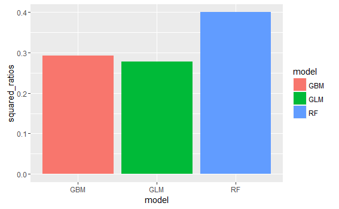

```r
ggplot(data=results, aes(x = model, y = squared_ratios, fill = model)) +
 geom_bar(stat="identity", position = "dodge")
```

As we can see the random forest had the best score above all others, although the rate was not too impressive, so let´s use it and see what more this model has to tell us.

```r
RF_summary <- summary(RF)
```

```
Model Details:
==============

H2ORegressionModel: drf
Model Key:  DRF_model_R_1477243664145_242
Model Summary:
  number_of_trees number_of_internal_trees model_size_in_bytes
1              50                       50              431192
  min_depth max_depth mean_depth min_leaves max_leaves mean_leaves
1        19        20   19.94000        294        849   681.30000

H2ORegressionMetrics: drf
** Reported on training data. **
** Metrics reported on Out-Of-Bag training samples **

MSE:  339102.6
RMSE:  582.3252
MAE:  226.5663
RMSLE:  1.166771
Mean Residual Deviance :  339102.6


H2ORegressionMetrics: drf
** Reported on validation data. **

MSE:  228748
RMSE:  478.2761
MAE:  195.3498
RMSLE:  1.130537
Mean Residual Deviance :  228748




Scoring History:
            timestamp   duration number_of_trees training_rmse
1 2016-10-23 20:49:58  0.003 sec               0
2 2016-10-23 20:49:58  0.012 sec               1     804.38679
3 2016-10-23 20:49:58  0.021 sec               2     751.94285
4 2016-10-23 20:49:58  0.029 sec               3     678.41282
```

[output cut: 34 more lines]

```
50        228273.89458
51        228747.98951

Variable Importances: (Extract with `h2o.varimp`)
=================================================

Variable Importances:
    variable relative_importance scaled_importance percentage
1    PROD_ID   5758912512.000000          1.000000   0.226696
2  MIN_PRICE   4524772352.000000          0.785699   0.178115
3 MEAN_PRICE   4128257792.000000          0.716847   0.162506
4        DAY   3647966464.000000          0.633447   0.143600
5   SD_PRICE   2659613696.000000          0.461826   0.104694
6  MAX_PRICE   2469554176.000000          0.428823   0.097212
7      MONTH   2214638592.000000          0.384558   0.087178
```

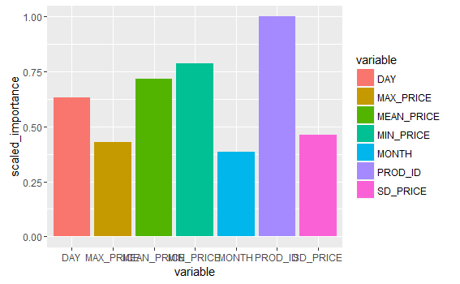

```r
g <- ggplot(data = RF_summary, aes(x = variable, y = scaled_importance, fill = variable)) +
geom_bar(stat = "identity", position = "dodge")
g
```

We found out that the field YEAR was irrelavant for the set, so we can remove it, but for meanings of futher inspection we´ll let it be. We could detect the principals fields within the summary of the model:

- PROD_ID
- DAY
- MEAN_PRICE
- MIN_PRICE

It appears that some produtcs sell more than others and some days are more important as well, problably it has something to do with the day of week. The mean and min could work together as lower prices would decrease the mean and make the product more affordable.

Let´s see if we can make it even more precise.

```r
RF2 <- h2o.randomForest(
    x = fields,
    y = "QTY_ORDER",
    training_frame = train,
    validation_frame = test,
    ntrees = 75,
    max_depth = 35,
    seed = 1234
  )
```

```
Dropping constant columns: [YEAR].
```

```r
  h2o.r2(RF2, valid = T)
```

```
[1] 0.4140149
```

```r
merged_data <-
  mutate(merged_data,
  WD = wday(ymd(paste(
    YEAR, sprintf("%02d", MONTH), sprintf("%02d", DAY), sep = ""))),
    WEEK = lubridate::week(ymd(paste(
    YEAR, sprintf("%02d", MONTH), sprintf("%02d", DAY), sep = ""))))

  mean_prices_wd <- group_by(merged_data, WD) %>%
  summarise(MEAN_WD = median(MIN_PRICE))


  mean_prices_week <- group_by(merged_data, WEEK) %>%
  summarise(MEAN_WEEK = median(MIN_PRICE))


  merged_data <- merge(merged_data, mean_prices_wd)

  merged_data <- mutate(merged_data,
                DIF_WD = MEDIAN_PRICE / MEAN_WD,
                DIF_WEEK = MEDIAN_PRICE / WEEK)

  tail(merged_data)
```

|  | WD | PROD_ID | YEAR | MONTH | DAY | QTY_ORDER | MIN_PRICE | MAX_PRICE | MEAN_PRICE | SD_PRICE | MEDIAN_PRICE | WEEK | MEAN_WD | DIF_WD | DIF_WEEK |
| --- | --- | --- | --- | --- | --- | --- | --- | --- | --- | --- | --- | --- | --- | --- | --- |
| 1913 | 7 | P4 | 2015 | 10 | 3 | 108 | 492.15 | 497 | 493.7667 | 2.3879749 | 492.150 | 40 | 738.63 | 0.6663011 | 12.30375 |
| 1914 | 7 | P7 | 2015 | 1 | 3 | 915 | 703.12 | 799 | 771.8340 | 38.6591560 | 799.000 | 1 | 738.63 | 1.0817324 | 799.00000 |
| 1915 | 7 | P3 | 2015 | 9 | 12 | 1 | 1002.32 | 1499 | 1188.8814 | 124.3456555 | 1185.575 | 37 | 738.63 | 1.6051000 | 32.04257 |
| 1916 | 7 | P2 | 2015 | 4 | 4 | 131 | 695.13 | 879 | 790.7672 | 59.9173717 | 760.710 | 14 | 738.63 | 1.0298932 | 54.33643 |
| 1917 | 7 | P5 | 2015 | 7 | 4 | 23 | 797.05 | 799 | 798.1750 | 0.7030776 | 798.000 | 27 | 738.63 | 1.0803785 | 29.55556 |
| 1918 | 7 | P3 | 2015 | 8 | 8 | 3 | 1099.00 | 1499 | 1213.2857 | 184.0174825 | 1099.000 | 32 | 738.63 | 1.4878897 | 34.34375 |

Let´s see how our model goes now.

```r
fields <- setdiff(setdiff(names(train), "QTY_ORDER"), "MEDIAN_PRICE")
merged_data.hex <-
  as.h2o(merged_data, destination_frame = "merged_data2.hex")
data_to_model <-
  h2o.splitFrame(data = merged_data.hex ,
                 ratios = 0.80,
                 seed = 1234)
train <- data_to_model[[1]]
test <- data_to_model[[2]]
RF3 <- h2o.randomForest(
  x = fields,
  y = "QTY_ORDER",
  training_frame = train,
  validation_frame = test,
  ntrees = 150,
  max_depth = 45,
  seed = 1234
)
```

```
Dropping constant columns: [YEAR].
```

```r
h2o.r2(RF3, valid = T)
```

```
[1] 0.4717004
```

We could get a precision of 47% this time. Let´s see how this new tunning changed the model.

[output not shown]

[output cut: 34 more lines]

```
150        295450.05837
151        295811.86385

Variable Importances: (Extract with `h2o.varimp`)
=================================================

Variable Importances:
    variable relative_importance scaled_importance percentage
1    PROD_ID  16743229440.000000          1.000000   0.226808
2  MIN_PRICE  14175352832.000000          0.846632   0.192023
3 MEAN_PRICE  10871889920.000000          0.649331   0.147273
4        DAY  10690825216.000000          0.638516   0.144820
5   SD_PRICE   7796886016.000000          0.465674   0.105618
6  MAX_PRICE   7446653952.000000          0.444756   0.100874
7      MONTH   6096412160.000000          0.364112   0.082583
```

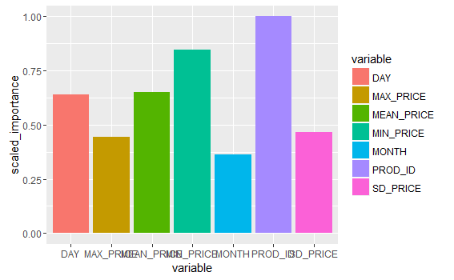

```r
ggplot(data=F3_summary, aes(x = variable, y = scaled_importance, fill = variable)) +
 geom_bar(stat="identity", position = "dodge")
```

There were some increasing in importance for the fields, specially the MIN_PRICE. Now our model had a good precison gain.